# examples_0206

Remember pythagorean theorem (for finding a side length from the other two side lengths).

$$(\text{adj})^2+(\text{opp})^2=(\text{hyp})^2$$

Remember SOH-CAH-TOA (for relating side-length ratios to angles).

$$\sin(\theta)=\frac{\text{opp}}{\text{hyp}}$$
$$\cos(\theta)=\frac{\text{adj}}{\text{hyp}}$$
$$\tan(\theta)=\frac{\text{opp}}{\text{adj}}$$

Use the appropriate equation.

$$13.4^2+x^2=39.6^2$$
$$x=\sqrt{1568.16-179.56}$$

$$x=37.3$$

On the right triangle below, find the unknown length or angle (in degrees).

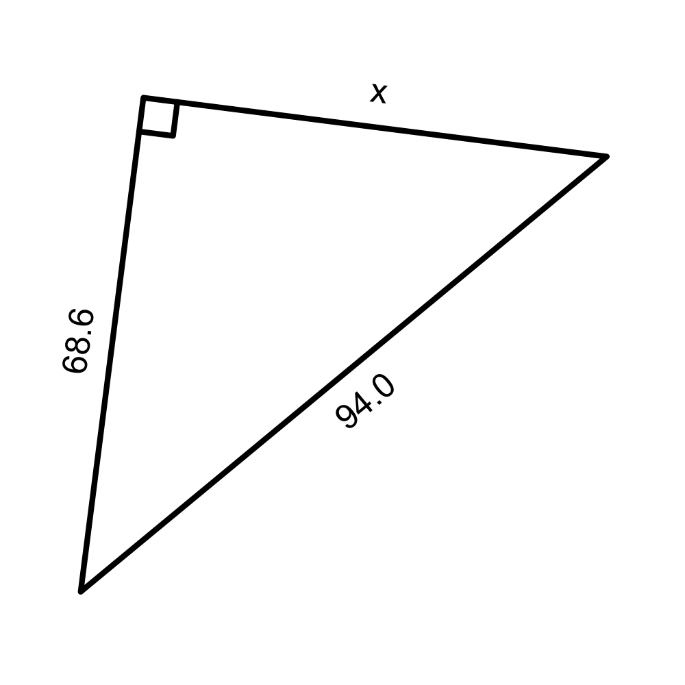

The tolerance is $\pm 0.1$.

Remember pythagorean theorem (for finding a side length from the other two side lengths).

$$(\text{adj})^2+(\text{opp})^2=(\text{hyp})^2$$

Remember SOH-CAH-TOA (for relating side-length ratios to angles).

$$\sin(\theta)=\frac{\text{opp}}{\text{hyp}}$$
$$\cos(\theta)=\frac{\text{adj}}{\text{hyp}}$$
$$\tan(\theta)=\frac{\text{opp}}{\text{adj}}$$

Use the appropriate equation.

$$68.6^2+x^2=94^2$$
$$x=\sqrt{8836-4705.96}$$

$$x=64.3$$

On the right triangle below, find the unknown length or angle (in degrees).

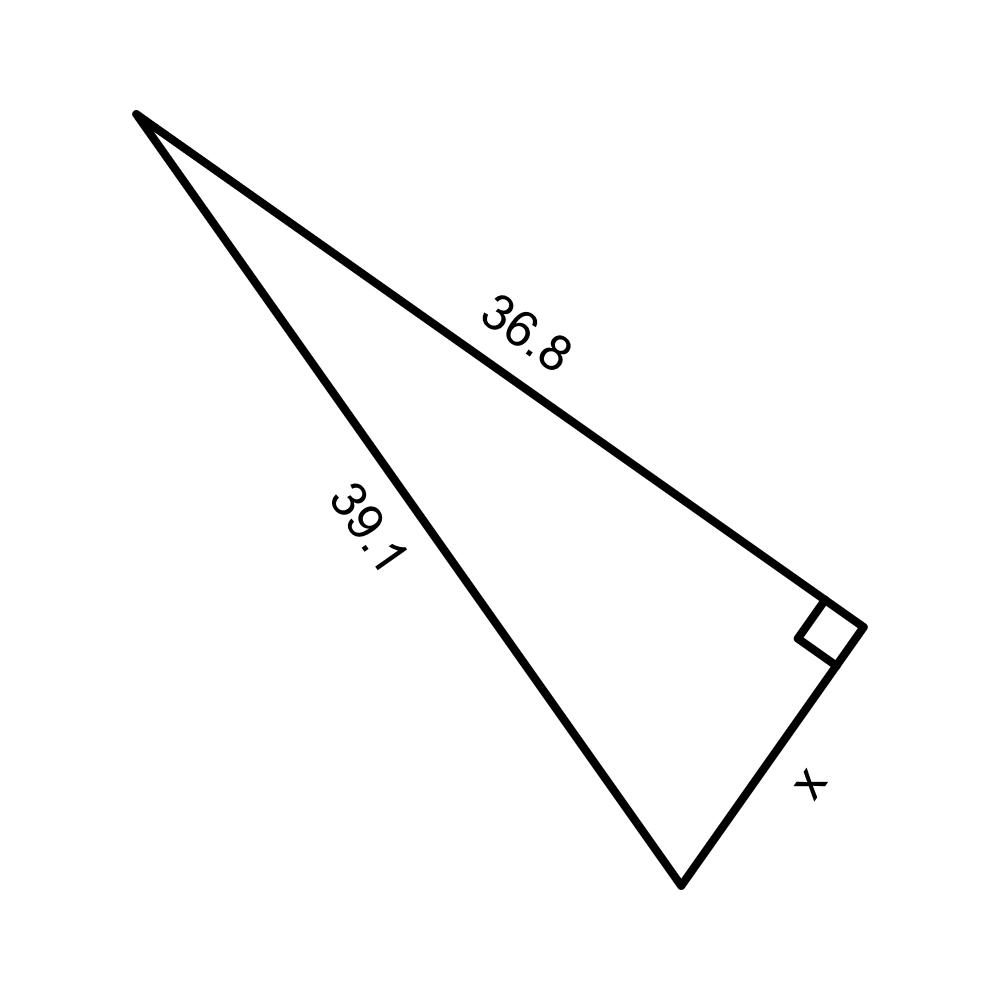

The tolerance is $\pm 0.1$.

Remember pythagorean theorem (for finding a side length from the other two side lengths).

$$(\text{adj})^2+(\text{opp})^2=(\text{hyp})^2$$

Remember SOH-CAH-TOA (for relating side-length ratios to angles).

$$\sin(\theta)=\frac{\text{opp}}{\text{hyp}}$$
$$\cos(\theta)=\frac{\text{adj}}{\text{hyp}}$$
$$\tan(\theta)=\frac{\text{opp}}{\text{adj}}$$

Use the appropriate equation.

$$36.8^2+x^2=39.1^2$$
$$x=\sqrt{1528.81-1354.24}$$

$$x=13.2$$